# chapter8_case_study2_v2

## Case study 2: Sleep Health and Lifestyle Analysis

### Key Features of the Dataset:

- **Comprehensive Sleep Metrics:** Explore sleep duration, quality, and factors influencing sleep patterns.
- **Lifestyle Factors:** Analyze physical activity levels, stress levels, and BMI categories.
- **Cardiovascular Health:** Examine blood pressure and heart rate measurements.
- **Sleep Disorder Analysis:** Identify the occurrence of sleep disorders such as Insomnia and Sleep Apea.

kaggle: https://www.kaggle.com/datasets/uom190346a/sleep-health-and-lifestyle-dataset/data

```python
import pandas as pd
import numpy as np
import matplotlib.pyplot as plt
```

## Part 1: Loading, Examining and Cleaning Data

```python
# Load the data and output the first ten rows to do an examination on data
df_raw = pd.read_csv('kaggle_sleep_health_life_style/Sleep_health_and_lifestyle_dataset.csv')
df_raw.head(10)
```

|  | Person ID | Gender | Age | Occupation | Sleep Duration | Quality of Sleep | Physical Activity Level | Stress Level | BMI Category | Blood Pressure | Heart Rate | Daily Steps | Sleep Disorder |
| --- | --- | --- | --- | --- | --- | --- | --- | --- | --- | --- | --- | --- | --- |
| 0 | 1 | Male | 27 | Software Engineer | 6.1 | 6 | 42 | 6 | Overweight | 126/83 | 77 | 4200 | NaN |
| 1 | 2 | Male | 28 | Doctor | 6.2 | 6 | 60 | 8 | Normal | 125/80 | 75 | 10000 | NaN |
| 2 | 3 | Male | 28 | Doctor | 6.2 | 6 | 60 | 8 | Normal | 125/80 | 75 | 10000 | NaN |
| 3 | 4 | Male | 28 | Sales Representative | 5.9 | 4 | 30 | 8 | Obese | 140/90 | 85 | 3000 | Sleep Apnea |
| 4 | 5 | Male | 28 | Sales Representative | 5.9 | 4 | 30 | 8 | Obese | 140/90 | 85 | 3000 | Sleep Apnea |
| 5 | 6 | Male | 28 | Software Engineer | 5.9 | 4 | 30 | 8 | Obese | 140/90 | 85 | 3000 | Insomnia |
| 6 | 7 | Male | 29 | Teacher | 6.3 | 6 | 40 | 7 | Obese | 140/90 | 82 | 3500 | Insomnia |
| 7 | 8 | Male | 29 | Doctor | 7.8 | 7 | 75 | 6 | Normal | 120/80 | 70 | 8000 | NaN |
| 8 | 9 | Male | 29 | Doctor | 7.8 | 7 | 75 | 6 | Normal | 120/80 | 70 | 8000 | NaN |
| 9 | 10 | Male | 29 | Doctor | 7.8 | 7 | 75 | 6 | Normal | 120/80 | 70 | 8000 | NaN |

observation:

- the first 10 rows data indicate there are a number duplicate entries, for example, IDs 2 and 3, IDs 4 and 5, and IDs 8, 9 and 10. So we need drop the duplicate entries.
- column Sleep Disorder has NaN entry, and we check with the original dataset, it is not missing data, but represents the individual does not exhibit any specific sleep disorder

```python
# check the column information and null values
df_raw.info()
```

```
<class 'pandas.core.frame.DataFrame'>
RangeIndex: 374 entries, 0 to 373
Data columns (total 13 columns):
 #   Column                   Non-Null Count  Dtype
---  ------                   --------------  -----
 0   Person ID                374 non-null    int64
 1   Gender                   374 non-null    object
 2   Age                      374 non-null    int64
 3   Occupation               374 non-null    object
 4   Sleep Duration           374 non-null    float64
 5   Quality of Sleep         374 non-null    int64
 6   Physical Activity Level  374 non-null    int64
 7   Stress Level             374 non-null    int64
 8   BMI Category             374 non-null    object
 9   Blood Pressure           374 non-null    object
 10  Heart Rate               374 non-null    int64
 11  Daily Steps              374 non-null    int64
 12  Sleep Disorder           155 non-null    object
dtypes: float64(1), int64(7), object(5)
memory usage: 38.1+ KB
```

observation:

- aside Sleep Disorder column, all other columns don't have null values
- Sleep Disorder column has 155 non-null values, the remaining null values represents the individual does not exhibit any specific sleep disorder as discussed before, so we need to fill them with other meaningful values

```python
# Identify duplicates starting from the second column
duplicates = df_raw.duplicated(subset=df_raw.columns[1:]).sum()
print("total duplicate entries: ", duplicates)

# Remove duplicates
df_cleaned = df_raw.drop_duplicates(subset=df_raw.columns[1:])
df_cleaned.info()
```

```
total duplicate entries:  242
<class 'pandas.core.frame.DataFrame'>
Index: 132 entries, 0 to 366
Data columns (total 13 columns):
 #   Column                   Non-Null Count  Dtype
---  ------                   --------------  -----
 0   Person ID                132 non-null    int64
 1   Gender                   132 non-null    object
 2   Age                      132 non-null    int64
 3   Occupation               132 non-null    object
 4   Sleep Duration           132 non-null    float64
 5   Quality of Sleep         132 non-null    int64
 6   Physical Activity Level  132 non-null    int64
 7   Stress Level             132 non-null    int64
 8   BMI Category             132 non-null    object
 9   Blood Pressure           132 non-null    object
 10  Heart Rate               132 non-null    int64
 11  Daily Steps              132 non-null    int64
 12  Sleep Disorder           59 non-null     object
dtypes: float64(1), int64(7), object(5)
memory usage: 14.4+ KB
```

observation: there are a large number of duplicate entries, close to two-third of the original data, so we drop all of them

```python
# fill null values with other meaningful values
df_cleaned.fillna("No Disorder", inplace = True)
df_cleaned.info()
```

```
<class 'pandas.core.frame.DataFrame'>
Index: 132 entries, 0 to 366
Data columns (total 13 columns):
 #   Column                   Non-Null Count  Dtype
---  ------                   --------------  -----
 0   Person ID                132 non-null    int64
 1   Gender                   132 non-null    object
 2   Age                      132 non-null    int64
 3   Occupation               132 non-null    object
 4   Sleep Duration           132 non-null    float64
 5   Quality of Sleep         132 non-null    int64
 6   Physical Activity Level  132 non-null    int64
 7   Stress Level             132 non-null    int64
 8   BMI Category             132 non-null    object
 9   Blood Pressure           132 non-null    object
 10  Heart Rate               132 non-null    int64
 11  Daily Steps              132 non-null    int64
 12  Sleep Disorder           132 non-null    object
dtypes: float64(1), int64(7), object(5)
memory usage: 14.4+ KB
```

```python
# Find unique values for BMI Category and Sleep Disorder
unique_bmi_categories = df_cleaned['BMI Category'].unique()
unique_sleep_disorders = df_cleaned['Sleep Disorder'].unique()

# Display the unique values
print("Unique values for BMI Category:", unique_bmi_categories)
print("Unique values for Sleep Disorder:", unique_sleep_disorders)
```

```
Unique values for BMI Category: ['Overweight' 'Normal' 'Obese' 'Normal Weight']
Unique values for Sleep Disorder: ['No Disorder' 'Sleep Apnea' 'Insomnia']
```

```python
# Replace "Normal Weight" with "Normal" and "Overweight" with "Obese" in the BMI Category column
df_cleaned['BMI Category'] = df_cleaned['BMI Category'].replace('Normal Weight', 'Normal')
df_cleaned['BMI Category'] = df_cleaned['BMI Category'].replace('Overweight', 'Obese')
unique_bmi_categories = df_cleaned['BMI Category'].unique()
print("Unique values for BMI Category:", unique_bmi_categories)
```

```
Unique values for BMI Category: ['Obese' 'Normal']
```

observation: since BMI Category and Sleep Disorder values are categorical data type, we need to convert them to numeric values with order

```python
# Separate Blood Pressure into Systolic and Diastolic
df_cleaned[['Systolic', 'Diastolic']] = df_cleaned['Blood Pressure'].str.split('/', expand=True)
df_cleaned['Systolic'] = df_cleaned['Systolic'].astype(int)
df_cleaned['Diastolic'] = df_cleaned['Diastolic'].astype(int)

# Drop the original Blood Pressure column
df_cleaned = df_cleaned.drop(columns=['Blood Pressure'])

# Map BMI Category to numerical values
df_cleaned['BMI Category'] = df_cleaned['BMI Category'].map({'Normal': 0, 'Obese': 1})
df_cleaned['Sleep Disorder'] = df_cleaned['Sleep Disorder'].map({'No Disorder': 0, 'Sleep Apnea': 1, 'Insomnia': 2})
# Verify the mapping
print("Mapped values for BMI Category:", df_cleaned['BMI Category'].unique())
print("Mapped values for Sleep Disorder:", df_cleaned['Sleep Disorder'].unique())
```

```
Mapped values for BMI Category: [1 0]
Mapped values for Sleep Disorder: [0 1 2]
```

```python
df_cleaned.head()
```

|  | Person ID | Gender | Age | Occupation | Sleep Duration | Quality of Sleep | Physical Activity Level | Stress Level | BMI Category | Heart Rate | Daily Steps | Sleep Disorder | Systolic | Diastolic |
| --- | --- | --- | --- | --- | --- | --- | --- | --- | --- | --- | --- | --- | --- | --- |
| 0 | 1 | Male | 27 | Software Engineer | 6.1 | 6 | 42 | 6 | 1 | 77 | 4200 | 0 | 126 | 83 |
| 1 | 2 | Male | 28 | Doctor | 6.2 | 6 | 60 | 8 | 0 | 75 | 10000 | 0 | 125 | 80 |
| 3 | 4 | Male | 28 | Sales Representative | 5.9 | 4 | 30 | 8 | 1 | 85 | 3000 | 1 | 140 | 90 |
| 5 | 6 | Male | 28 | Software Engineer | 5.9 | 4 | 30 | 8 | 1 | 85 | 3000 | 2 | 140 | 90 |
| 6 | 7 | Male | 29 | Teacher | 6.3 | 6 | 40 | 7 | 1 | 82 | 3500 | 2 | 140 | 90 |

```python
df_cleaned.describe()
```

|  | Person ID | Age | Sleep Duration | Quality of Sleep | Physical Activity Level | Stress Level | BMI Category | Heart Rate | Daily Steps | Sleep Disorder | Systolic | Diastolic |
| --- | --- | --- | --- | --- | --- | --- | --- | --- | --- | --- | --- | --- |
| count | 132.000000 | 132.000000 | 132.000000 | 132.000000 | 132.000000 | 132.000000 | 132.000000 | 132.000000 | 132.000000 | 132.000000 | 132.000000 | 132.000000 |
| mean | 171.727273 | 41.128788 | 7.082576 | 7.151515 | 58.393939 | 5.537879 | 0.446970 | 71.204545 | 6637.878788 | 0.666667 | 128.363636 | 84.537879 |
| std | 110.418779 | 8.813942 | 0.775335 | 1.269037 | 20.468840 | 1.740428 | 0.499074 | 4.867306 | 1766.288657 | 0.816497 | 7.825650 | 6.049926 |
| min | 1.000000 | 27.000000 | 5.800000 | 4.000000 | 30.000000 | 3.000000 | 0.000000 | 65.000000 | 3000.000000 | 0.000000 | 115.000000 | 75.000000 |
| 25% | 79.500000 | 33.750000 | 6.400000 | 6.000000 | 44.250000 | 4.000000 | 0.000000 | 68.000000 | 5000.000000 | 0.000000 | 120.750000 | 80.000000 |
| 50% | 166.500000 | 41.000000 | 7.150000 | 7.000000 | 60.000000 | 6.000000 | 0.000000 | 70.000000 | 7000.000000 | 0.000000 | 130.000000 | 85.000000 |
| 75% | 268.250000 | 49.000000 | 7.725000 | 8.000000 | 75.000000 | 7.000000 | 1.000000 | 74.000000 | 8000.000000 | 1.000000 | 135.000000 | 88.500000 |
| max | 367.000000 | 59.000000 | 8.500000 | 9.000000 | 90.000000 | 8.000000 | 1.000000 | 86.000000 | 10000.000000 | 2.000000 | 142.000000 | 95.000000 |

## Part 2: Exploratory Data Analysis¶

Correlation Analysis: To investigate the correlation among the variables, we create the correlation heatmap, and the values in the cells in the heatmap represent the correlation coefficients between two variables. A positive correlation coefficient indicates a positive linear relationship between two variables and the relationship is that as one variable increases, the other variable also tends to increase. A negative correlation coefficient indicates a negative linear relationship between two variables and the relationship is that as one variable increases, the other variable tends to decrease.

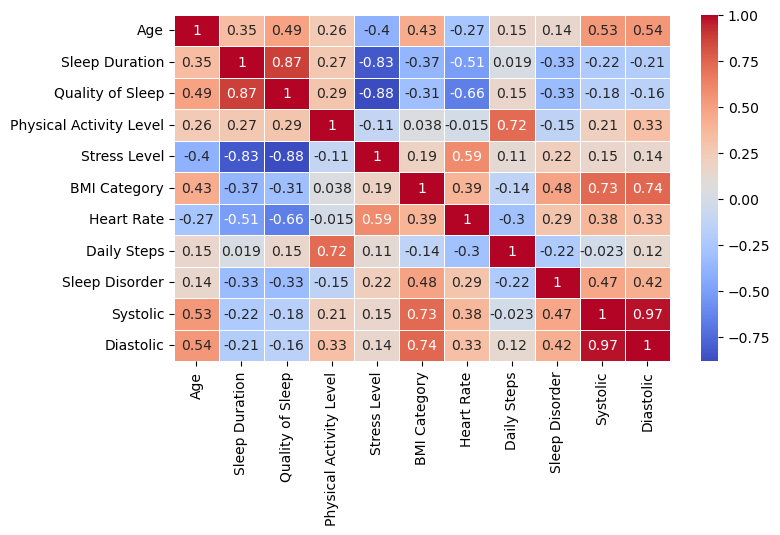

```python
import seaborn as sns
# Drop non-numeric columns for correlation calculation
df_numeric = df_cleaned.drop(columns=['Person ID', 'Gender', 'Occupation'])
# Calculate the correlation matrix
corr_matrix = df_numeric.corr()

# Set up the matplotlib figure
plt.figure(figsize=(8, 4.5))
# Draw the heatmap with the mask and correct aspect ratio
sns.heatmap(corr_matrix, annot=True, cmap='coolwarm', linewidths=.5)
# Show the plot
plt.show()
```

observation:  
Strong correlation (abs of coefficient > 0.5):

- Age with blood pressure(Systolic, Diastolic).
- Sleep Duration with Quality of Sleep, Stress Level, Heart Rate.
- Quality of Sleep with Sleep Duration, Stress Level, Heart Rate.
- Physical Activity Level with Daily Steps.
- BMI Category with blood pressure(Systolic, Diastolic).

Explore Quality of Sleep and Blood Pressure distribution among different Age Group, Gender Group and Occupation Group

```python
# for age, we use four different quantitle groups from the description data: <25%, 25% - 50%, 50% - 75%, >75%
```

```python
df_numeric['Age_levels'] = pd.qcut(df_numeric['Age'], q=4, labels = [ 'Twenties', 'Thirties', 'Forties', 'Fifties'])
df_for_groups = df_numeric
df_for_groups.head()
```

|  | Age | Sleep Duration | Quality of Sleep | Physical Activity Level | Stress Level | BMI Category | Heart Rate | Daily Steps | Sleep Disorder | Systolic | Diastolic | Age_levels |
| --- | --- | --- | --- | --- | --- | --- | --- | --- | --- | --- | --- | --- |
| 0 | 27 | 6.1 | 6 | 42 | 6 | 1 | 77 | 4200 | 0 | 126 | 83 | Twenties |
| 1 | 28 | 6.2 | 6 | 60 | 8 | 0 | 75 | 10000 | 0 | 125 | 80 | Twenties |
| 3 | 28 | 5.9 | 4 | 30 | 8 | 1 | 85 | 3000 | 1 | 140 | 90 | Twenties |
| 5 | 28 | 5.9 | 4 | 30 | 8 | 1 | 85 | 3000 | 2 | 140 | 90 | Twenties |
| 6 | 29 | 6.3 | 6 | 40 | 7 | 1 | 82 | 3500 | 2 | 140 | 90 | Twenties |

```python
# group the dataframe by age and find the mean values for the variables
df_by_age = df_for_groups.groupby(['Age_levels']).mean()
df_by_age.tail(8)
```

| Age_levels | Age | Sleep Duration | Quality of Sleep | Physical Activity Level | Stress Level | BMI Category | Heart Rate | Daily Steps | Sleep Disorder | Systolic | Diastolic |
| --- | --- | --- | --- | --- | --- | --- | --- | --- | --- | --- | --- |
| Twenties | 30.424242 | 6.800000 | 6.272727 | 50.515152 | 6.727273 | 0.151515 | 73.181818 | 6339.393939 | 0.454545 | 124.484848 | 81.696970 |
| Thirties | 37.486486 | 7.175676 | 7.486486 | 60.108108 | 4.972973 | 0.243243 | 70.783784 | 6586.486486 | 0.432432 | 124.270270 | 81.351351 |
| Forties | 44.636364 | 6.781818 | 6.757576 | 61.272727 | 5.939394 | 0.818182 | 71.666667 | 6736.363636 | 1.151515 | 132.424242 | 87.454545 |
| Fifties | 53.965517 | 7.627586 | 8.172414 | 61.896552 | 4.448276 | 0.620690 | 68.965517 | 6931.034483 | 0.655172 | 133.379310 | 88.517241 |

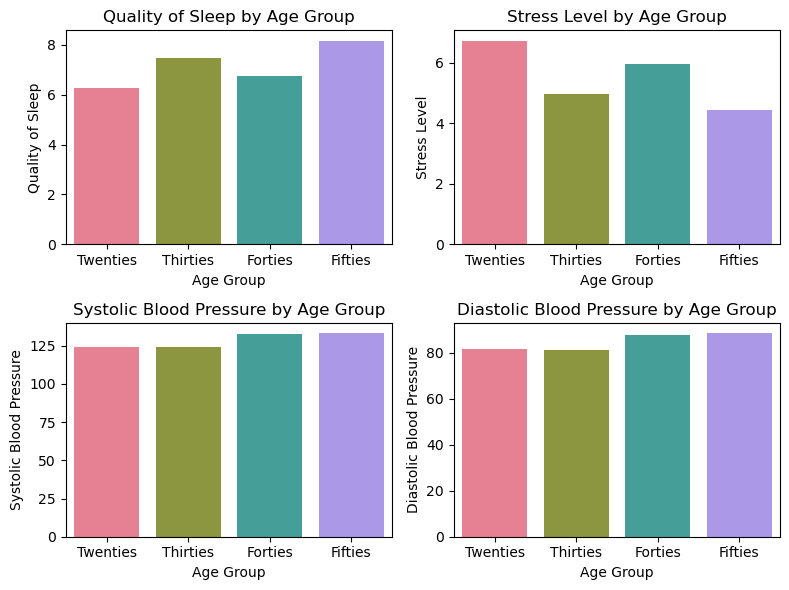

```python
# Create bar plots for Quality of Sleep, Stress Level, Systolic, and Diastolic
plt.figure(figsize=(8, 6))

#palette = ["red", "green", "blue", "purple"]
# Quality of Sleep
plt.subplot(2, 2, 1)
sns.barplot(x=df_by_age.index, y='Quality of Sleep', data=df_by_age, palette='husl')
plt.title('Quality of Sleep by Age Group')
plt.xlabel('Age Group')
plt.ylabel('Quality of Sleep')

# Stress Level
plt.subplot(2, 2, 2)
sns.barplot(x=df_by_age.index, y='Stress Level', data=df_by_age, palette='husl')
plt.title('Stress Level by Age Group')
plt.xlabel('Age Group')
plt.ylabel('Stress Level')

# Systolic
plt.subplot(2, 2, 3)
sns.barplot(x=df_by_age.index, y='Systolic', data=df_by_age, palette='husl')
plt.title('Systolic Blood Pressure by Age Group')
plt.xlabel('Age Group')
plt.ylabel('Systolic Blood Pressure')

# Diastolic
plt.subplot(2, 2, 4)
sns.barplot(x=df_by_age.index, y='Diastolic', data=df_by_age, palette='husl')
plt.title('Diastolic Blood Pressure by Age Group')
plt.xlabel('Age Group')
plt.ylabel('Diastolic Blood Pressure')

plt.tight_layout()
plt.show()
```

```python
# group the dataframe by gender and find the mean values for the variables
df_by_gender = df_cleaned.drop(columns=['Person ID', 'Occupation']).groupby(['Gender']).mean()
df_by_gender.tail(8)
```

| Gender | Age | Sleep Duration | Quality of Sleep | Physical Activity Level | Stress Level | BMI Category | Heart Rate | Daily Steps | Sleep Disorder | Systolic | Diastolic |
| --- | --- | --- | --- | --- | --- | --- | --- | --- | --- | --- | --- |
| Female | 45.830769 | 7.152308 | 7.446154 | 59.061538 | 4.969231 | 0.553846 | 70.507692 | 6707.692308 | 0.723077 | 129.938462 | 86.123077 |
| Male | 36.567164 | 7.014925 | 6.865672 | 57.746269 | 6.089552 | 0.343284 | 71.880597 | 6570.149254 | 0.611940 | 126.835821 | 83.000000 |

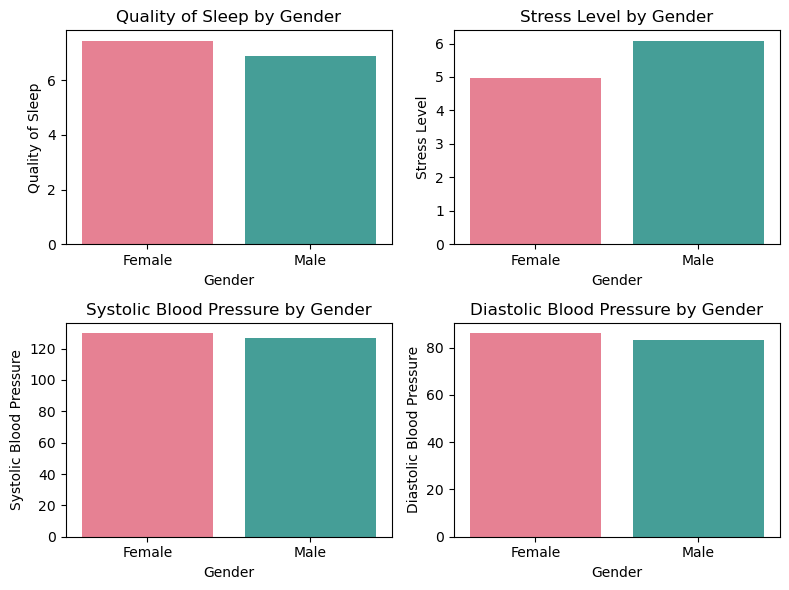

```python
# Create bar plots for Quality of Sleep, Stress Level, Systolic, and Diastolic
plt.figure(figsize=(8, 6))

# Quality of Sleep
plt.subplot(2, 2, 1)
sns.barplot(x=df_by_gender.index, y='Quality of Sleep', data=df_by_gender, palette='husl')
plt.title('Quality of Sleep by Gender')
plt.xlabel('Gender')
plt.ylabel('Quality of Sleep')

# Stress Level
plt.subplot(2, 2, 2)
sns.barplot(x=df_by_gender.index, y='Stress Level', data=df_by_gender, palette='husl')
plt.title('Stress Level by Gender')
plt.xlabel('Gender')
plt.ylabel('Stress Level')

# Systolic
plt.subplot(2, 2, 3)
sns.barplot(x=df_by_gender.index, y='Systolic', data=df_by_gender, palette='husl')
plt.title('Systolic Blood Pressure by Gender')
plt.xlabel('Gender')
plt.ylabel('Systolic Blood Pressure')

# Diastolic
plt.subplot(2, 2, 4)
sns.barplot(x=df_by_gender.index, y='Diastolic', data=df_by_gender, palette='husl')
plt.title('Diastolic Blood Pressure by Gender')
plt.xlabel('Gender')
plt.ylabel('Diastolic Blood Pressure')

plt.tight_layout()
plt.show()
```

observation:

- the Quality of Sleep: Female is better than male
- Stress Level: Male is higher than female
- Blood Pressure(Systolic/Diastolic): Both are close to each other

```python
# group the dataframe by Occupation and find the mean values for the variables
df_by_occupation = df_cleaned.drop(columns=['Person ID', 'Gender']).groupby(['Occupation']).mean()
df_by_occupation.tail(8)
```

| Occupation | Age | Sleep Duration | Quality of Sleep | Physical Activity Level | Stress Level | BMI Category | Heart Rate | Daily Steps | Sleep Disorder | Systolic | Diastolic |
| --- | --- | --- | --- | --- | --- | --- | --- | --- | --- | --- | --- |
| Lawyer | 39.133333 | 7.380000 | 7.733333 | 69.000000 | 5.133333 | 0.200000 | 71.400000 | 7073.333333 | 0.466667 | 130.200000 | 85.200000 |
| Manager | 45.000000 | 6.900000 | 7.000000 | 55.000000 | 5.000000 | 1.000000 | 75.000000 | 5500.000000 | 0.000000 | 125.000000 | 82.000000 |
| Nurse | 48.241379 | 6.965517 | 7.068966 | 73.172414 | 5.758621 | 0.758621 | 72.862069 | 7558.620690 | 0.793103 | 136.275862 | 91.793103 |
| Sales Representative | 28.000000 | 5.900000 | 4.000000 | 30.000000 | 8.000000 | 1.000000 | 85.000000 | 3000.000000 | 1.000000 | 140.000000 | 90.000000 |
| Salesperson | 43.333333 | 6.422222 | 6.000000 | 45.000000 | 7.000000 | 1.000000 | 72.000000 | 6000.000000 | 1.444444 | 130.000000 | 85.000000 |
| Scientist | 33.500000 | 6.000000 | 5.000000 | 41.000000 | 7.000000 | 1.000000 | 78.500000 | 5350.000000 | 0.500000 | 129.500000 | 85.500000 |
| Software Engineer | 30.000000 | 6.500000 | 6.000000 | 44.000000 | 6.333333 | 0.666667 | 77.333333 | 5066.666667 | 0.666667 | 128.666667 | 84.333333 |
| Teacher | 39.800000 | 6.720000 | 6.800000 | 45.000000 | 5.000000 | 0.800000 | 69.133333 | 5780.000000 | 1.266667 | 129.733333 | 85.466667 |

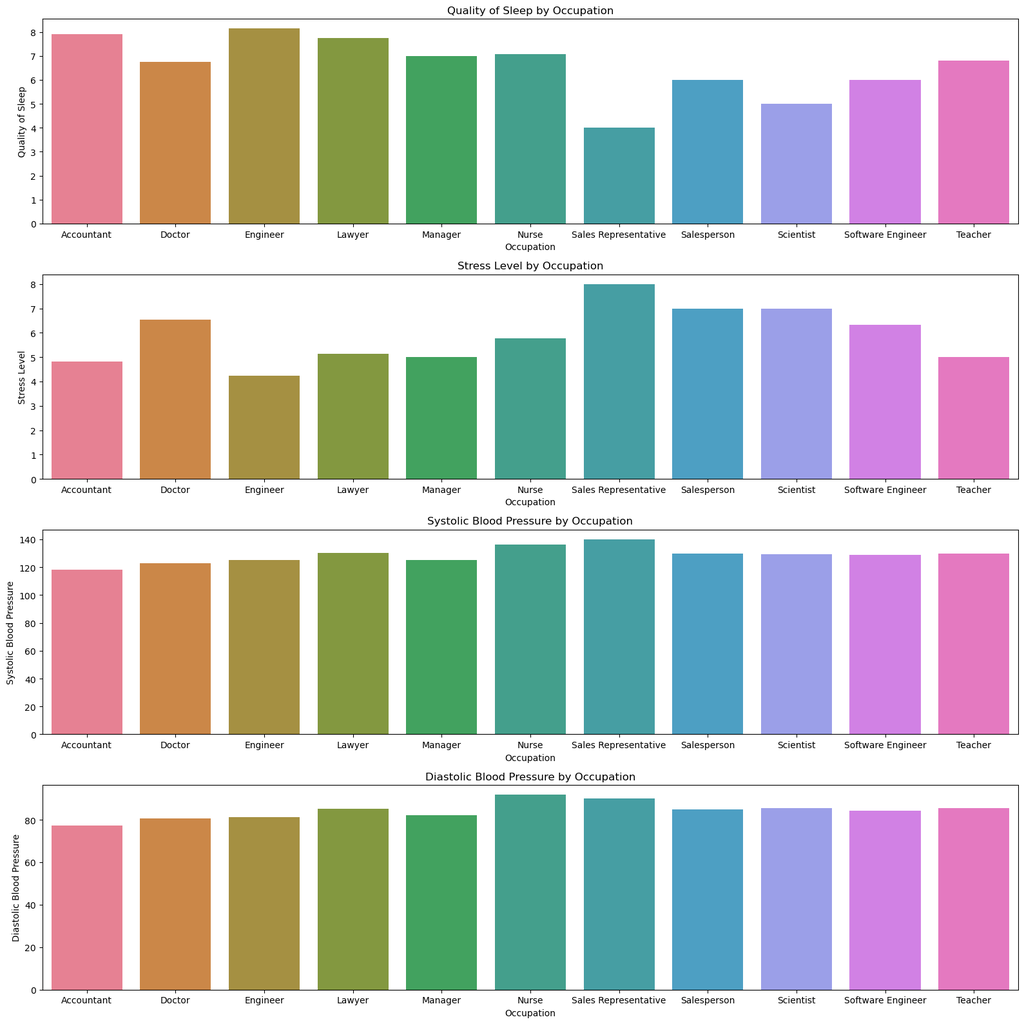

```python
# Create bar plots for Quality of Sleep, Stress Level, Systolic, and Diastolic
plt.figure(figsize=(16, 16))

# Quality of Sleep
plt.subplot(4, 1, 1)
sns.barplot(x=df_by_occupation.index, y='Quality of Sleep', data=df_by_occupation, palette='husl')
plt.title('Quality of Sleep by Occupation')
plt.xlabel('Occupation')
plt.ylabel('Quality of Sleep')

# Stress Level
plt.subplot(4, 1, 2)
sns.barplot(x=df_by_occupation.index, y='Stress Level', data=df_by_occupation, palette='husl')
plt.title('Stress Level by Occupation')
plt.xlabel('Occupation')
plt.ylabel('Stress Level')

# Systolic
plt.subplot(4, 1, 3)
sns.barplot(x=df_by_occupation.index, y='Systolic', data=df_by_occupation, palette='husl')
plt.title('Systolic Blood Pressure by Occupation')
plt.xlabel('Occupation')
plt.ylabel('Systolic Blood Pressure')

# Diastolic
plt.subplot(4, 1, 4)
sns.barplot(x=df_by_occupation.index, y='Diastolic', data=df_by_occupation, palette='husl')
plt.title('Diastolic Blood Pressure by Occupation')
plt.xlabel('Occupation')
plt.ylabel('Diastolic Blood Pressure')

plt.tight_layout()
plt.show()
```

observation:

- the Quality of Sleep: Engineers hold the highest quality with mean of above 8 while Sales Representative has the lowest with mean of 4
- Stress Level: Engineers hold the lowest score while Sales Representative has the highest score
- Blood Pressure(Systolic/Diastolic): Sales Representative and Nurse are higher than the normal range of values

## Part 3: Modeling

We want to see if there is any linear regression relationship between Quality of Sleep with factors from Age, Physical Activity Level, Stress Level and BMI Category, so we perform linear regression using both scikit learn library and statsmodel library.

```
Mean Squared Error: 0.10748491626199712
R^2 Score: 0.9286370637932642
                         Coefficient
Age                         0.046515
Physical Activity Level     0.009742
Stress Level               -0.494812
BMI Category               -0.841243
```

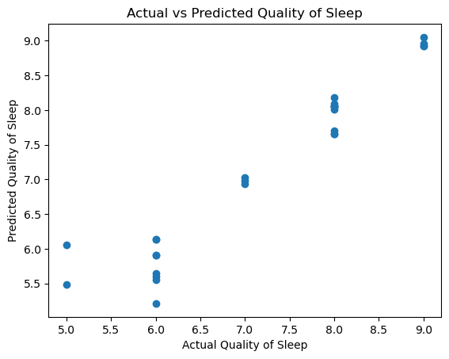

```python
from sklearn.model_selection import train_test_split
from sklearn.linear_model import LinearRegression
from sklearn.metrics import mean_squared_error, r2_score

# Features and target variable
X = df_cleaned[['Age', 'Physical Activity Level', 'Stress Level', 'BMI Category']]
y = df_cleaned['Quality of Sleep']

# Split the data into training and testing sets
X_train, X_test, y_train, y_test = train_test_split(X, y, test_size=0.2, random_state=42)

# Create the regression model
model = LinearRegression()

# Train the model
model.fit(X_train, y_train)

# Make predictions
y_pred = model.predict(X_test)

# Evaluate the model
mse = mean_squared_error(y_test, y_pred)
r2 = r2_score(y_test, y_pred)

print(f'Mean Squared Error: {mse}')
print(f'R^2 Score: {r2}')

# Display the coefficients
coefficients = pd.DataFrame(model.coef_, X.columns, columns=['Coefficient'])
print(coefficients)

# Plotting the true vs predicted values
plt.scatter(y_test, y_pred)
plt.xlabel("Actual Quality of Sleep")
plt.ylabel("Predicted Quality of Sleep")
plt.title("Actual vs Predicted Quality of Sleep")
plt.show()
```

Observation:

- the MSE is 0.10748491626199712 which is low and is considered that the model's predictions are close to the actual values.
- the R² score is 0.9286370637932642 which is high and this indicates that approximately 93% of the variance in Quality of Sleep is explained by the model's predictors (Age, Physical Activity Level, Stress Level, and BMI Category).

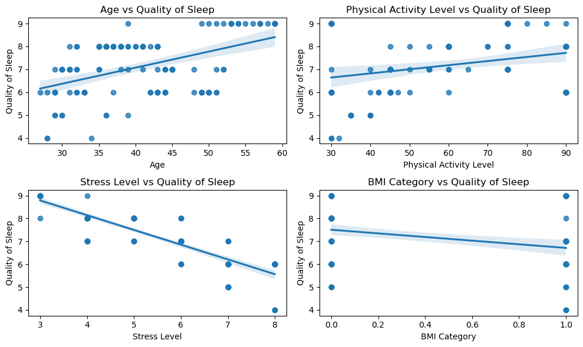

```python
# Plotting the regression line with confidence interval
plt.figure(figsize=(10, 6))

# Age vs Quality of Sleep
plt.subplot(2, 2, 1)
sns.regplot(x='Age', y='Quality of Sleep', data=df_cleaned, ci=95)
plt.title('Age vs Quality of Sleep')

# Physical Activity Level vs Quality of Sleep
plt.subplot(2, 2, 2)
sns.regplot(x='Physical Activity Level', y='Quality of Sleep', data=df_cleaned, ci=95)
plt.title('Physical Activity Level vs Quality of Sleep')

# Stress Level vs Quality of Sleep
plt.subplot(2, 2, 3)
sns.regplot(x='Stress Level', y='Quality of Sleep', data=df_cleaned, ci=95)
plt.title('Stress Level vs Quality of Sleep')

# BMI Category vs Quality of Sleep
plt.subplot(2, 2, 4)
sns.regplot(x='BMI Category', y='Quality of Sleep', data=df_cleaned, ci=95)
plt.title('BMI Category vs Quality of Sleep')

plt.tight_layout()
plt.show()
```

```python
import statsmodels.api as sm

# Add a constant to the model (intercept)
X = sm.add_constant(X)

# Fit the regression model using statsmodels
model = sm.OLS(y, X).fit()

# Print the summary of the regression model
print(model.summary())
```

```
                            OLS Regression Results
==============================================================================
Dep. Variable:       Quality of Sleep   R-squared:                       0.901
Model:                            OLS   Adj. R-squared:                  0.898
Method:                 Least Squares   F-statistic:                     290.3
Date:                Thu, 01 Aug 2024   Prob (F-statistic):           7.49e-63
Time:                        16:37:27   Log-Likelihood:                -65.342
No. Observations:                 132   AIC:                             140.7
Df Residuals:                     127   BIC:                             155.1
Df Model:                           4
Covariance Type:            nonrobust
===========================================================================================
                              coef    std err          t      P>|t|      [0.025      0.975]
-------------------------------------------------------------------------------------------
const                       7.8206      0.300     26.033      0.000       7.226       8.415
Age                         0.0463      0.005      8.432      0.000       0.035       0.057
Physical Activity Level     0.0092      0.002      5.112      0.000       0.006       0.013
Stress Level               -0.4933      0.025    -19.938      0.000      -0.542      -0.444
BMI Category               -0.8430      0.088     -9.585      0.000      -1.017      -0.669
==============================================================================
Omnibus:                        6.530   Durbin-Watson:                   2.014
Prob(Omnibus):                  0.038   Jarque-Bera (JB):                8.583
Skew:                          -0.253   Prob(JB):                       0.0137
Kurtosis:                       4.142   Cond. No.                         639.
==============================================================================

Notes:
[1] Standard Errors assume that the covariance matrix of the errors is correctly specified.
```

Observation: R² = 0.901 is high and close to 1, indicating that the model fits well. The p-values of all predictors are less than 0.05 indicating they are significant, with Stress Level and BMI Category having a negative impact on Quality of Sleep, while Age and Physical Activity Level have a positive impact.

Omnibus and Jarque-Bera tests indicate some potential issues with the normality of residuals, but the Durbin-Watson statistic suggests no autocorrelation in the residuals.

The condition number tests for multicollinearity and it is 639, which is quite high, indicating potential multicollinearity problems.

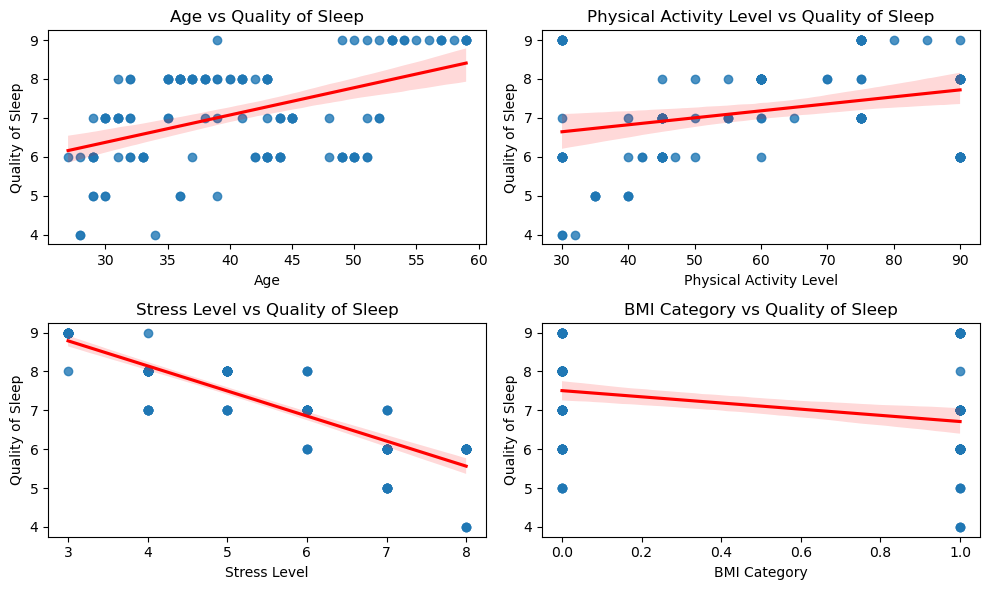

```python
# Create a new DataFrame with predictions for the line plot
df_cleaned['Predicted Quality of Sleep'] = model.predict(X)

# Plotting the regression line with confidence interval
plt.figure(figsize=(10, 6))

# Age vs Quality of Sleep
plt.subplot(2, 2, 1)
sns.regplot(x='Age', y='Quality of Sleep', data=df_cleaned, ci=95, line_kws={'color': 'red'})
plt.title('Age vs Quality of Sleep')

# Physical Activity Level vs Quality of Sleep
plt.subplot(2, 2, 2)
sns.regplot(x='Physical Activity Level', y='Quality of Sleep', data=df_cleaned, ci=95, line_kws={'color': 'red'})
plt.title('Physical Activity Level vs Quality of Sleep')

# Stress Level vs Quality of Sleep
plt.subplot(2, 2, 3)
sns.regplot(x='Stress Level', y='Quality of Sleep', data=df_cleaned, ci=95, line_kws={'color': 'red'})
plt.title('Stress Level vs Quality of Sleep')

# BMI Category vs Quality of Sleep
plt.subplot(2, 2, 4)
sns.regplot(x='BMI Category', y='Quality of Sleep', data=df_cleaned, ci=95, line_kws={'color': 'red'})
plt.title('BMI Category vs Quality of Sleep')

plt.tight_layout()
plt.show()
```